# Coronavirus Time Series Analysis: Are We Italy?

# Introduction

In analyzing the growth trajectories of the Coronavirus, a key question is whether the US and other countries are going to follow the explosion of cases and deaths in Italy or are going to level out, as is being experienced in China and South Korea.

My view is that in an exponential growth scenario (which we are experiencing), it is the *growth rate* that is all important rather than the nominal number of confirmed cases or deaths. This is what this analysis focuses on. A country with low infected numbers but a high growth rate will quickly overtake a country with high infections but low growth rate. For example, compare Italian vs. Chinese deaths below.

The growth rate will necessary and eventually convert from an exponential curve to a logistic curve (an “S”-shaped curve) as infection rates saturate a population. However, we are currently nowehere near the saturation point, and so, in the near term, a reduction in growth rate will have to be be driven by other sources.

The rest of this report compares the growth rate in confirmed Covid-19 cases and deaths for various countries. I fit a Gaussian Process curve to the data to smooth out the volatility and determine a mean for the growth rates. In particular, I have reviewed the “aligned” growth in confirmed cases and deaths. That is, for each country I aligned the data to start:

- For confirmed case analysis: The day when 200 cases were confirmed in each respective country
- For deaths analysis: The day when 10 deaths were confirmed in each respective country

All code and data can be found on [Github](https://github.com/howardnewyork/corona).

# Summary of Results

For US and other European countries, the news is uniformally bad. These countries seem to be following more the Italian model rather than the South Korean one.

I note that the Chinese data is so good that it seems suspect. They had only 25 new infections and 13 deaths on March 19. Given their early problems and wide exposure, the new data seem too good to be true.

In summary, there is an inkling of good news in the Italian data and hopefully the trend continues. South Korea and China (if the data are correct) show that the virus can be beat, BUT at this stage radical control of population movement is likely necessary (per Italian and Chinese model).

# Methodology

I used a Gaussian Process model to establish the mean growth rates. Raw growth rates were determined as:

- Confirmed case growth rate: $Confirmed~Case~ Growth~Rate_t = log(Confirmed~Cases_{t} / Confirmed~Cases_{t-1} )$
- Confirmed death growth rate: $Deaths~Case~ Growth~Rate_t = log(Confirmed~Deaths_{t} / Confirmed~Deaths_{t-1} )$

I then calculate a 95% credible around such mean estimate.

# Data Sources

[Johns Hopkins COID-19 Data Repository](https://github.com/CSSEGISandData/COVID-19/compare?expand=1)

Note: the data are very messy and dependent on differing testing regimes rather than true infection experience.

| province_state | country | lat | long | 1/22/20 |
| --- | --- | --- | --- | --- |
| NA | Thailand | 15.0000 | 101.0000 | 2 |
| NA | Japan | 36.0000 | 138.0000 | 2 |
| NA | Singapore | 1.2833 | 103.8333 | 0 |
| NA | Nepal | 28.1667 | 84.2500 | 0 |
| NA | Malaysia | 2.5000 | 112.5000 | 0 |

# Data Exploration

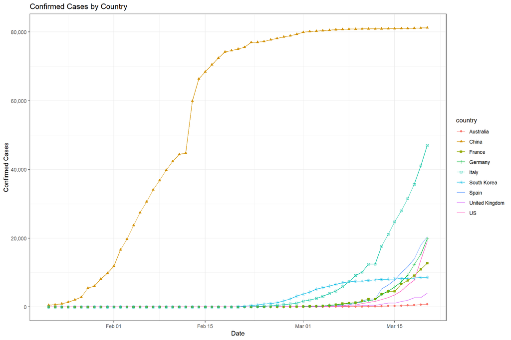

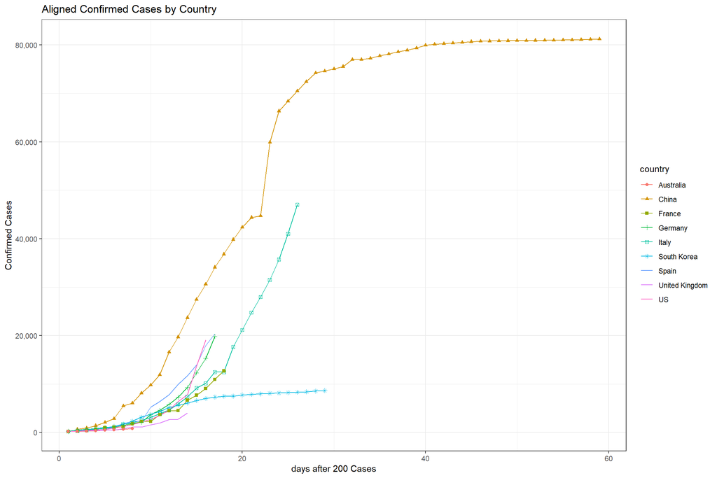

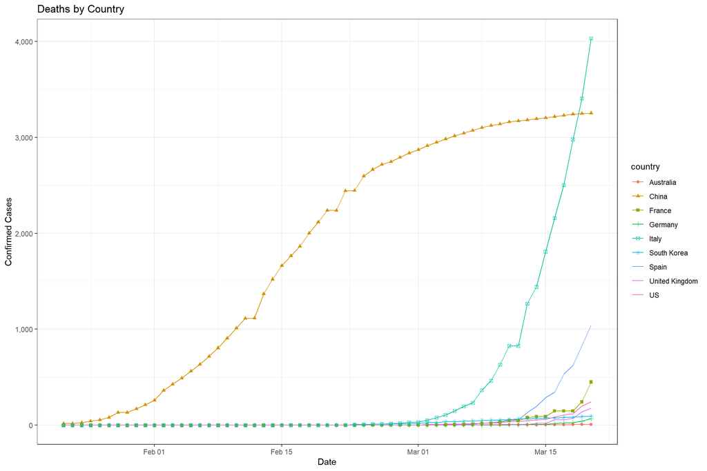

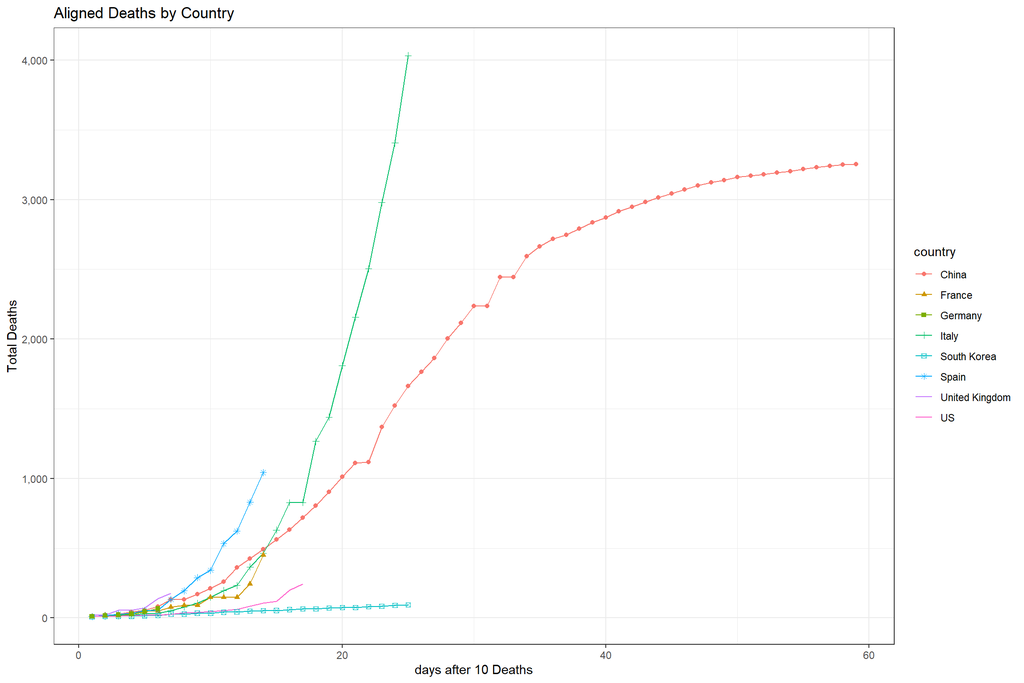

# Growth Rate Analysis

## Confirmed Cases

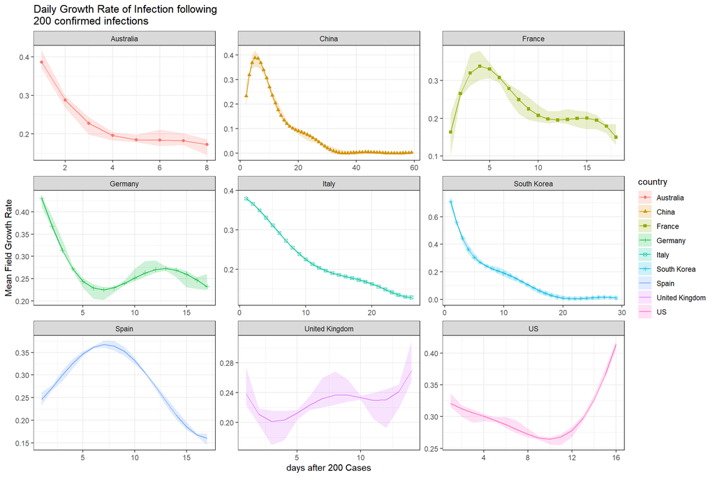

## Deaths

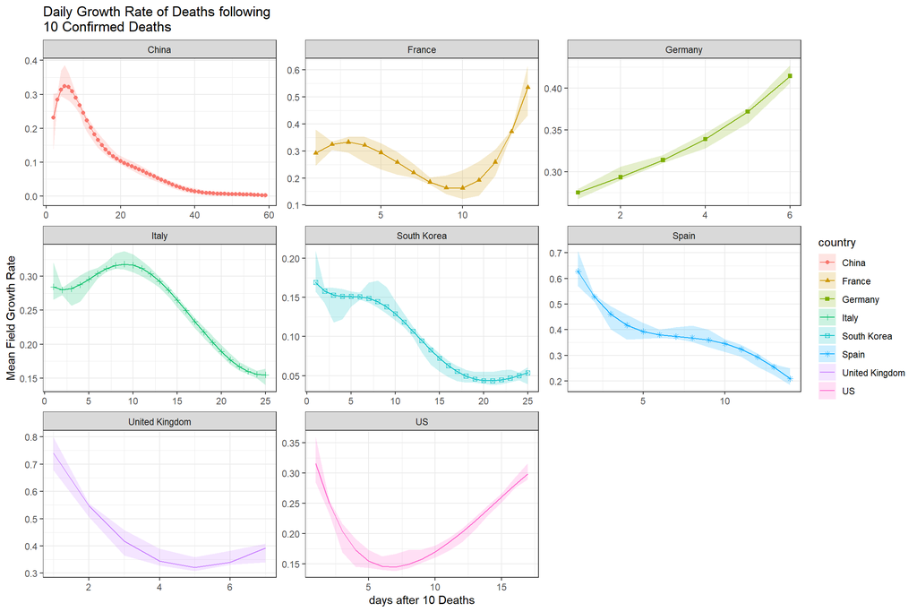

Note: UK death records are too limited to be reliable.